# TDA and TDAmapper

November 30, 2017

## What is TDA?

Topological Data Analysis (TDA) is a way of looking at the topology of data, rather than linear fits or probability models. What's the **shape** of data?

Pros: shape persists however you "rotate" your data (point of view matters less).

## Today: TDA with R

- Example of a circle with TDA and TDAmapper packages
- Example of an infinity symbol
- Stock data (messy, real life)

## Packages

```r
library(BatchGetSymbols)
library(reshape2)
library(TDA)
library(TDAmapper)
library(igraph)
```

## Circle first

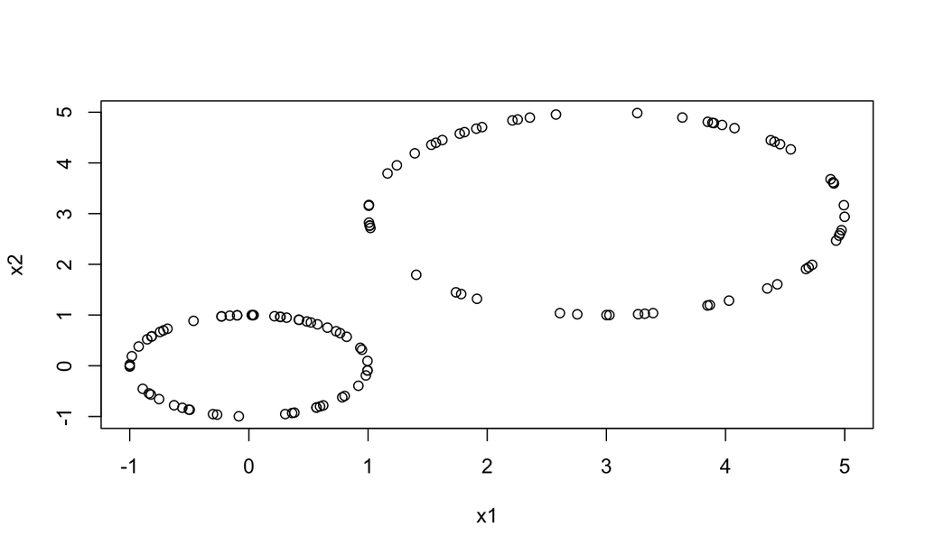

```r
circle1 <- circleUnif(60)
circle2 <- circleUnif(60,r=2)+3
circles <- rbind(circle1,circle2)
plot(circles)
```

## Circle persistence diagram

Persistence diagram: birth and death of homology classes

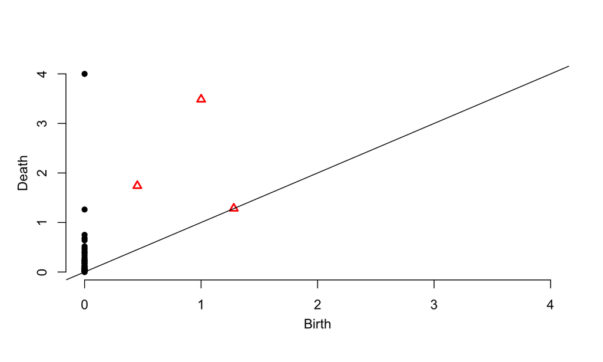

## TDAmapper for the circle

```r
circlemapper <- mapper1D(distance_matrix=dist(circles), filter_values = circles[,1],
  num_intervals =  12,
  percent_overlap = 50,
  num_bins_when_clustering =12)
g2 <- graph.adjacency(circlemapper$adjacency,
  mode="undirected")
```

## Plot result from TDAmapper for circles

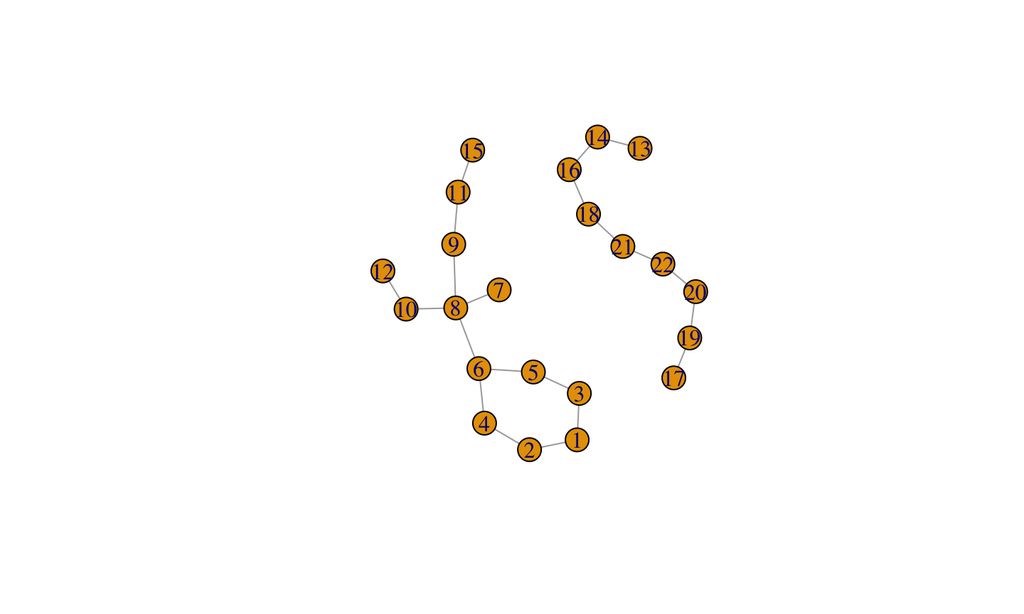

```r
plot(g2, layout = layout.auto(g2) )
```

## Infinity symbol

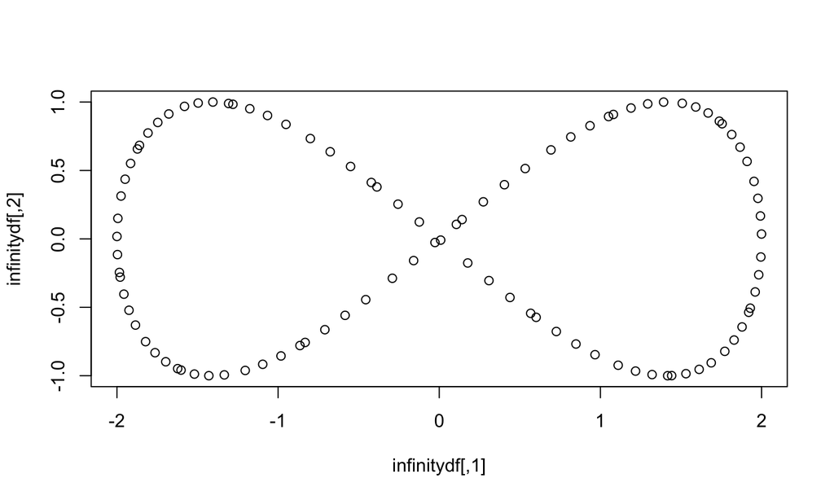

```r
infinitydf<- cbind(2*cos(0.5*(1:100)),sin(1:100))
plot(infinitydf)
```

## Persistence diagram

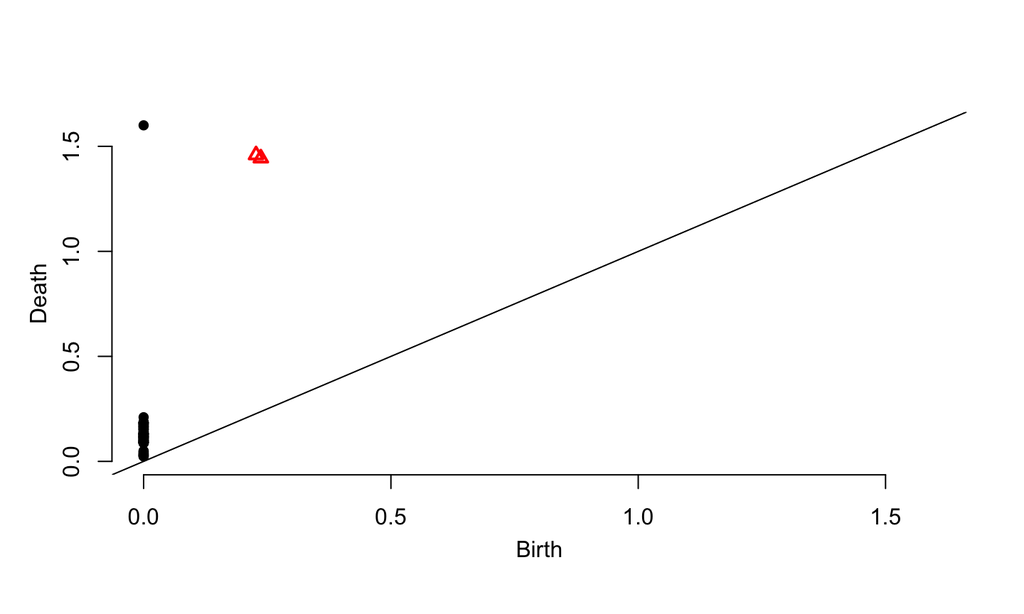

## TDAmapper

```r
infinitymapper <- mapper1D(distance_matrix=dist(infinitydf),
  filter_values = infinitydf[,1],
  num_intervals =  12,
  percent_overlap = 50,
  num_bins_when_clustering =12)

g2 <- graph.adjacency(infinitymapper$adjacency,
  mode="undirected")
```

## TDAmapper for infinity symbol

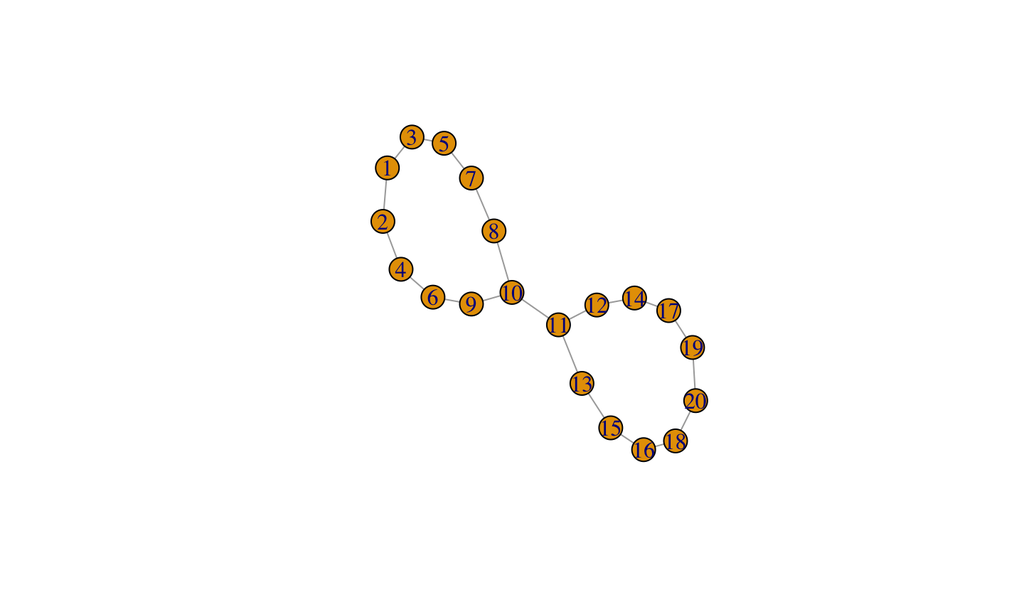

## Financial data!

- With students Jacqueline Cai and Hao Li at the University of Minnesota
- Inspired by paper "Topology Data Analysis Of Critical Transitions in Financial Networks" by Marian Gidea
- Visualize transition in stock correlations before crisis (?)

## Get stock data and make log returns matrix

```r
first.date <- as.Date('2004/01/01')
last.date <- as.Date('2009/09/30')
tickers <- c('MMM','AXP','AAPL','BA','CAT','CVX','CSCO','KO','DWDP','XOM','GE','GS','HD','IBM','INTC','JNJ','JPM','MCD','MRK','MSFT','NKE','PFE','PG','TRV','UNH','UTX','VZ','WMT','DIS')
data <- BatchGetSymbols(tickers = tickers,
                        first.date = first.date,
                        last.date = last.date)
```

```
##
## Running BatchGetSymbols for:
##    tickers = MMM, AXP, AAPL, BA, CAT, CVX, CSCO, KO, DWDP, XOM, GE, GS, HD, IBM, INTC, JNJ, JPM, MCD, MRK, MSFT, NKE, PFE, PG, TRV, UNH, UTX, VZ, WMT, DIS
```

```r
newdata <- BatchGetSymbols(tickers = tickers,
            first.date = as.Date('2017/05/01'),
            last.date = as.Date('2017/10/01'))
```

```
##
## Running BatchGetSymbols for:
##    tickers = MMM, AXP, AAPL, BA, CAT, CVX, CSCO, KO, DWDP, XOM, GE, GS, HD, IBM, INTC, JNJ, JPM, MCD, MRK, MSFT, NKE, PFE, PG, TRV, UNH, UTX, VZ, WMT, DIS
```

```r
widestock <- dcast(data$df.tickers[,6:8], ref.date ~ ticker, value.var="price.adjusted")
logrets <- apply(widestock[,2:30], 2,
                function(x) diff(log(x), lag=1))
```

## Make a correlation matrix for the log returns

Correlation matrices are really easy!

```r
first100cor <- cor(logrets[1:100,], method = "pearson")
second100cor <- cor(logrets[101:200,], method = "pearson")
```

## Graphing the correlation networks

Let's make a matrix by looking at a "super-level set," basically only showing edges when stocks have highly correlated log returns. Notice I'm making a "distance" matrix out of the correlation matrix.

```r
highcor100mat <- sqrt(2*(first100cor+1))
highcorsuperlevel100 <- ifelse (highcor100mat>1.8, highcor100mat,0)
network=graph_from_adjacency_matrix(highcorsuperlevel100,
        weighted=TRUE,
        mode="undirected",
        diag=F)
```

## Plot for first 100 days

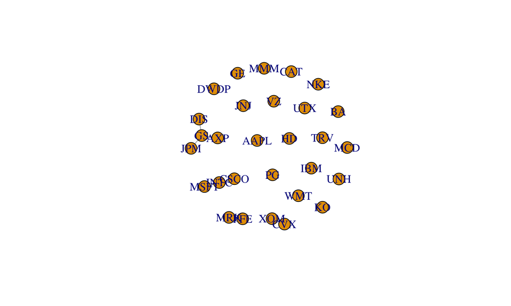

```r
plot(network)
```

## Plot for second 100 days

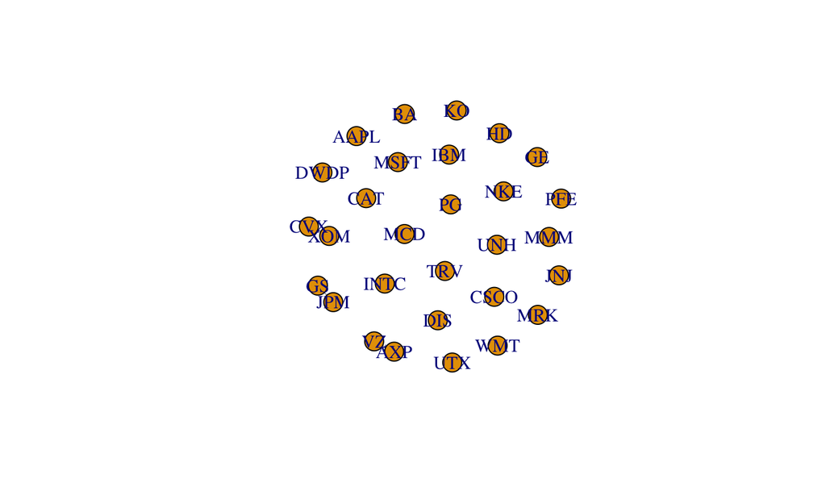

## Financial crisis 100 days

Look now at 100 days starting December 21, 2007.

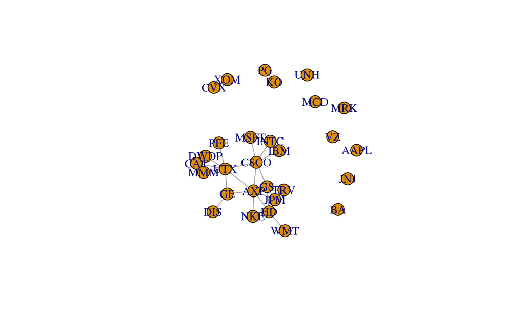

And now October-November-December 2008

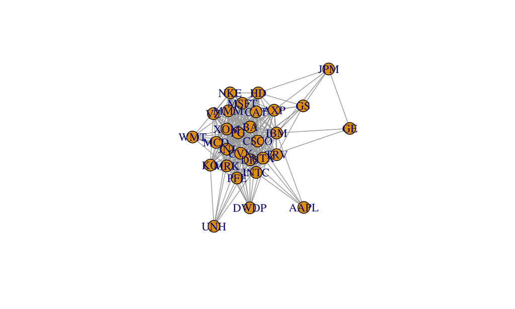

## Persistence diagram for stock data

We can make a persistence diagram for the stock data as well, to see if any "circles" exist or persist.

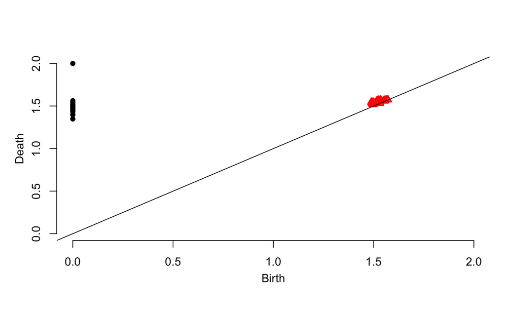

```r
first100persistence <- ripsDiag(highcor100mat,maxscale=2,maxdimension = 1,dist="arbitrary")

plot(first100persistence[["diagram"]])
```

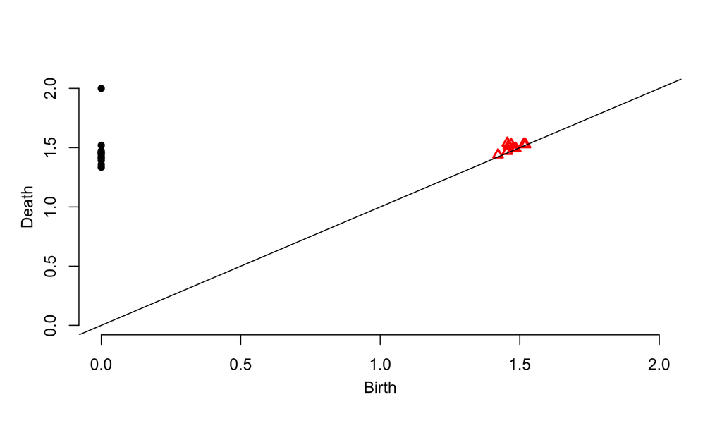

## 1001-1100 days

Persistence diagram for the network from 2007.

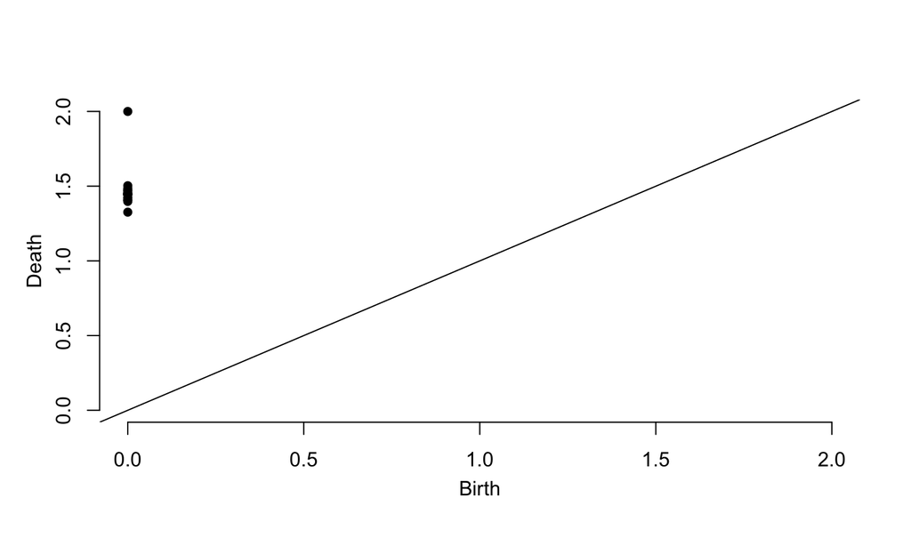

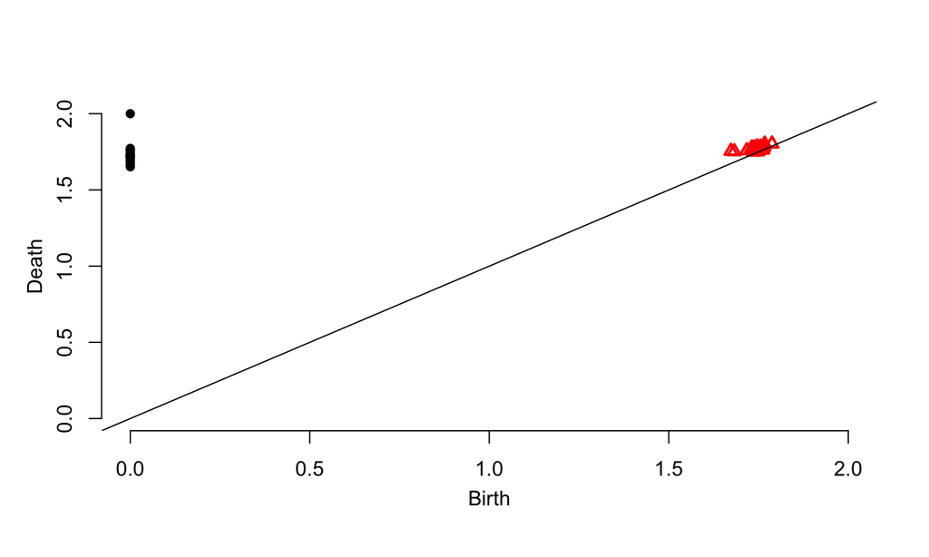

## What about now?

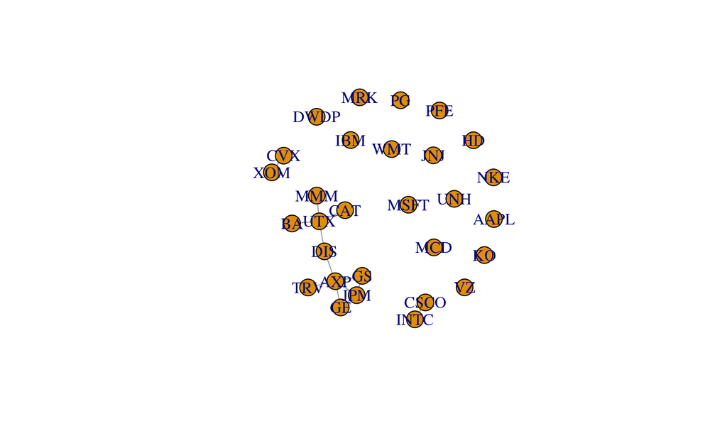